# Final Project: Oscar Predictions - Part 3

Nicholas Salisbury

2/27/2020

# Introduction

Every year, as the doldrums of winter are in full throat, Hollywood rolls out the red carpet for it’s biggest and brightest stars; that’s right, it’s Oscar season! For 92 years, the Academy of Motion Picture Arts and Sciencies have been handing out little gold statues for the best movies, actors/actresses, directors, writers, and various other film roles.

Shortly after the new year, speculation picks up about who and what will be nominated for an award. And as those nominations are announced, many people, from experts to casual moviegoers, try to guess who the winners will be. But instead of guessing, is there a way we can accurately predict the winners?

## Load Libraries

```r
library(readr)
library(ggplot2)
library(magrittr)
library(tidyr)
library(pastecs)
library(dplyr)
library(vcd)
```

## Data

My original data sets are from the following sources: * IMDb dataset links are below. Documentation for each set is located at: https://www.imdb.com/interfaces/. Please note that this data is updated daily by IMDb. But my data is from 2/10/2020. + [Personnel] (https://datasets.imdbws.com/name.basics.tsv.gz) + [Title Basics] (https://datasets.imdbws.com/title.basics.tsv.gz) + [Principal Cast and Crew] (https://datasets.imdbws.com/title.principals.tsv.gz] + [Writer and Directors by Title] (https://datasets.imdbws.com/title.crew.tsv.gz) + [Title Rating Stats] (https://datasets.imdbws.com/title.ratings.tsv.gz * [Previous Oscar winners] (https://www.kaggle.com/unanimad/the-oscar-award) * [Previous Golden Globe winners](https://www.kaggle.com/unanimad/golden-globe-awards) - This was unused

There is a ton of data in these files! And it is all normalized, which seems to make it hard to work with in R. Since my background is a database administrator, the best (easist) way for me to simplify my data set was to build a database and import the data into it. From there I was able to use SQL to join and filter data. I will provide the query utilized at the end of this write up, but for now, I will just list the filters and join conditions utilized in the SQL:

- Movies after 1927 as this was the year the films were first awarded
- Feature films and shorts, removing television shows and made for TV films
- Required more than 1000 votes from the IMDb community

Another concern that I’m sure limited my data set somewhat was that since the Oscar informationw as separate from the IMDb information, sometimes names (actors/actresses/directors/etc) or titles did not match up. I did my best to account for this by formatting the data in the join condition, such as removing all punctuation and spaces and ignoring case. But I’m sure there were some fringe cases that were not caught such as misspellings or the use of nicknames.

Once I had a query to generate a basic data set, I was able to bring the data into R and start a deeper dive.

```r
# Load data
oscar_preds <- read_csv("oscar-prediction-dataset-1000v.csv")
# Split comma separate genre column into multiple genre columns.
oscar_preds <- oscar_preds %>% separate(genres, c("genre_1", "genre_2", "genre_3"), ",", extra = "drop", fill = "right")

# Preview the data
head(oscar_preds)
```

```
## # A tibble: 6 x 14
##   primary_title genre_1 genre_2 genre_3 start_year have_win average_rating
##   <chr>         <chr>   <chr>   <chr>        <dbl>    <dbl>          <dbl>
## 1 '71           Action  Crime   Drama         2014        0            7.2
## 2 'Doc'         Western <NA>    <NA>          1971        0            6.1
## 3 'G' Men       Crime   Drama   Film-N~       1935        0            7.2
## 4 'Gung Ho!': ~ Drama   History War           1943        0            6.1
## 5 'night, Moth~ Drama   <NA>    <NA>          1986        0            7.6
## 6 'Pimpernel' ~ Advent~ Drama   Thrill~       1941        0            7.2
## # ... with 7 more variables: number_votes <dbl>, runtime_minutes <chr>,
## #   title_constant <chr>, prior_director_win <dbl>, prior_actor_win <dbl>,
## #   prior_writer_win <dbl>, prior_other_win <dbl>
```

```r
str(oscar_preds)
```

```
## tibble [30,838 x 14] (S3: tbl_df/tbl/data.frame)
##  $ primary_title     : chr [1:30838] "'71" "'Doc'" "'G' Men" "'Gung Ho!': The Story of Carlson's Makin Island Raiders" ...
##  $ genre_1           : chr [1:30838] "Action" "Western" "Crime" "Drama" ...
##  $ genre_2           : chr [1:30838] "Crime" NA "Drama" "History" ...
##  $ genre_3           : chr [1:30838] "Drama" NA "Film-Noir" "War" ...
##  $ start_year        : num [1:30838] 2014 1971 1935 1943 1986 ...
##  $ have_win          : num [1:30838] 0 0 0 0 0 0 0 1 0 0 ...
##  $ average_rating    : num [1:30838] 7.2 6.1 7.2 6.1 7.6 7.2 5.7 7.4 5.8 4.8 ...
##  $ number_votes      : num [1:30838] 47652 1226 3320 1196 2016 ...
##  $ runtime_minutes   : chr [1:30838] "99" "96" "85" "88" ...
##  $ title_constant    : chr [1:30838] "tt2614684" "tt0067003" "tt0026393" "tt0035958" ...
##  $ prior_director_win: num [1:30838] 0 0 0 0 0 0 0 0 0 0 ...
##  $ prior_actor_win   : num [1:30838] 0 0 0 0 1 0 0 0 0 0 ...
##  $ prior_writer_win  : num [1:30838] 0 0 0 0 0 1 0 0 0 0 ...
##  $ prior_other_win   : num [1:30838] 0 0 0 0 0 0 0 1 0 0 ...
```

```r
# I care mostly about the first genre, so check for NAs (should be NONE!)
any(is.na(oscar_preds$genre_1))
```

```
## [1] FALSE
```

In the original data set, there is a genre field with a comma-separate list of identified genres for the film. The above process will split that field into 3 separate fields. If there are not 3 identified genres (there is always at least 1 per the is.na check), the remaining 2 fields are set as NA. If there are more than 3 genres identified, they are thrown away.

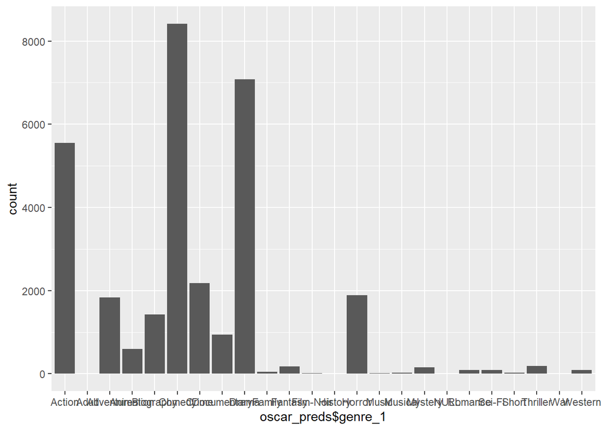

I’m sorry, but that is a pretty ugly graph. So I try to clean it up a bit by removing some genres. I made this decision because, while some of these genres have Oscar winners, I felt they are spreading out our data too much. Where as the majority of our films are in specific genres and these genres make up the majority of Oscar winners, let’s focus on them!

```r
# note some peculiar genres from graph above, review data
subset(oscar_preds, genre_1 == 'NULL' | genre_1 == 'Adult', select = c(primary_title))
```

```
## # A tibble: 4 x 1
##   primary_title
##   <chr>
## 1 Jane Fonda in Five Acts
## 2 Sexual Chronicles of a French Family
## 3 The Cleaners
## 4 The Sinful Dwarf
```

```r
## Remove 2 "adult" records. Convert 2 null to documentary based on additional research (The Cleaners and Jane Fonda in Five Acts)
oscar_preds$genre_1[oscar_preds$genre_1 == "NULL"] <- 'Documentary'
oscar_preds <- subset(oscar_preds, genre_1 != "Adult")

# Oscars seem to congregate around certain genre's. I think we should remove non-relevant genres
subset(subset(oscar_preds, have_win == 1) %>%
         group_by(genre_1) %>%
         tally(), n >= 40)
```

```
## # A tibble: 7 x 2
##   genre_1       n
##   <chr>     <int>
## 1 Action      113
## 2 Adventure   123
## 3 Animation    44
## 4 Biography   140
## 5 Comedy      175
## 6 Crime        64
## 7 Drama       324
```

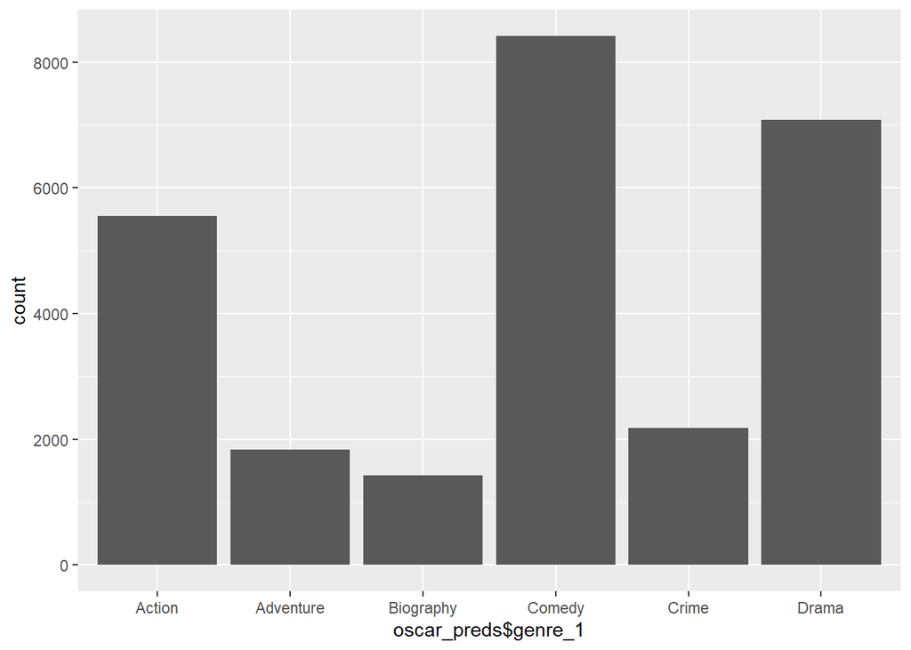

```r
# Remove everything not in specified genres
oscar_preds <- subset(oscar_preds, genre_1 %in% cbind("Action","Adventure","Biography","Comedy","Crime","Drama"))

# Re-plot genres again
ggplot(data=oscar_preds, aes(x=oscar_preds$genre_1)) +
  geom_bar()
```

Another way to reduce my overwhelming data set was to focus only on feature films. These are films identified by the academy as greater than 40 minutes. So I removed anything less than that. I also removed anything that was identified as a “short” in any of the genre fields. Other film institutions have different runtime requirements, so if a film was labeled as a short, I wanted to remove it.

```r
# a few runtimes were expressed as chars, resulting in the column be a char. convert to number
oscar_preds <- transform(oscar_preds, runtime_minutes = as.numeric(runtime_minutes))
```

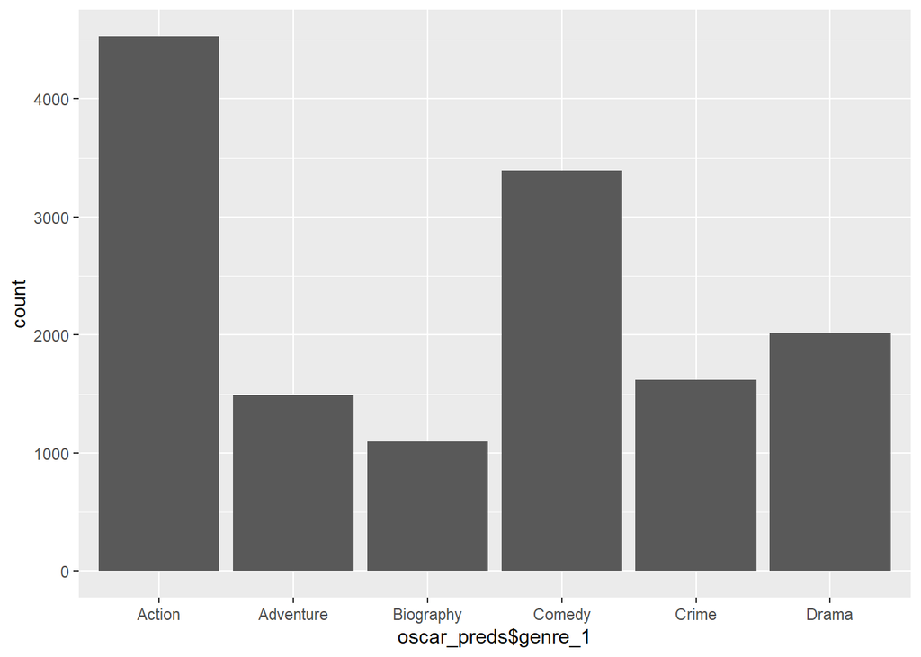

```r
# Throw away NAs and "shorts"
oscar_preds <- subset(oscar_preds, !is.na(oscar_preds$runtime_minutes) & oscar_preds$runtime_minutes > 40 & genre_1 != "Short"
                      & genre_2 != "Short" & genre_3 != "Short" )

# Re-plot genres again
ggplot(data=oscar_preds, aes(x=oscar_preds$genre_1)) +
  geom_bar()
```

So now that I *think* we have a reasonable dataset, I tried a couple of other graphs and functions to help understand my data.

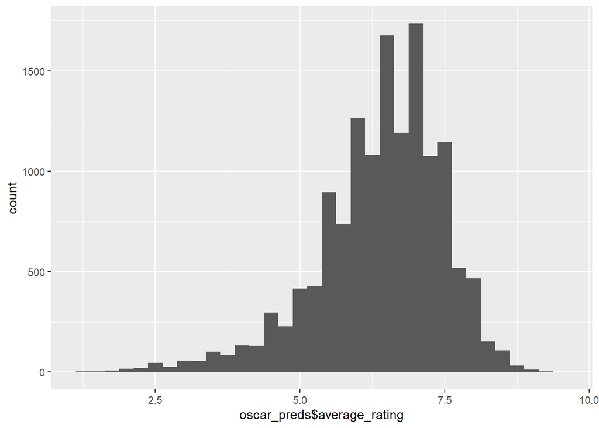

```r
# Check on the distribution of our average rating
ggplot(data=oscar_preds, aes(x=oscar_preds$average_rating)) +
  geom_histogram(binwidth = 0.25)
```

```r
stat.desc(oscar_preds[sample(nrow(oscar_preds), 5000), "average_rating"], basic = FALSE, norm = TRUE)
```

```
##        median          mean       SE.mean  CI.mean.0.95           var
##  6.500000e+00  6.394240e+00  1.516156e-02  2.972331e-02  1.149365e+00
##       std.dev      coef.var      skewness      skew.2SE      kurtosis
##  1.072084e+00  1.676641e-01 -8.207383e-01 -1.184989e+01  1.191463e+00
##      kurt.2SE    normtest.W    normtest.p
##  8.602940e+00  9.645708e-01  2.369460e-33
```

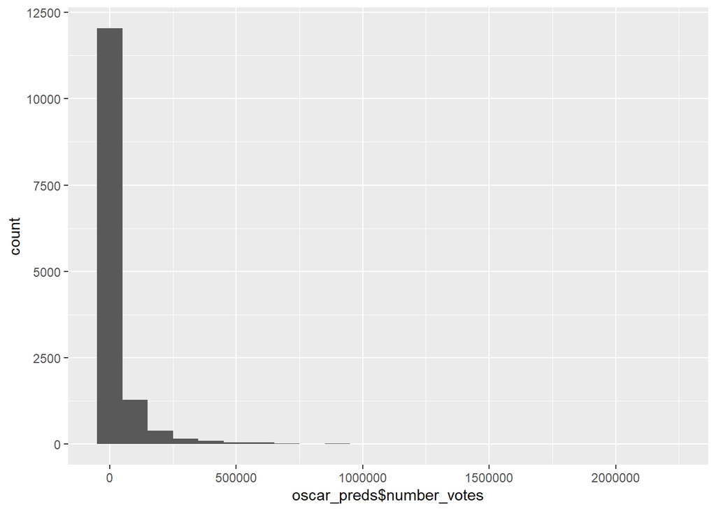

```r
# Check our distribution of number of votes... hmm something is askew here.
ggplot(data=oscar_preds, aes(x=oscar_preds$number_votes)) +
  geom_histogram(binwidth = 100000)
```

```r
# Whoa our skew and kurtosis is bad. As bad as your halitosis.
stat.desc(oscar_preds[sample(nrow(oscar_preds), 5000), "number_votes"], basic = FALSE, norm = TRUE)
```

```
##       median         mean      SE.mean CI.mean.0.95          var      std.dev
## 4.837500e+03 3.302854e+04 1.335348e+03 2.617867e+03 8.915766e+09 9.442334e+04
##     coef.var     skewness     skew.2SE     kurtosis     kurt.2SE   normtest.W
## 2.858840e+00 7.522379e+00 1.086088e+02 8.686872e+01 6.272343e+02 3.454608e-01
##   normtest.p
## 4.425473e-86
```

# Discuss how you plan to uncover new information in the data that is not self-evident

I wanted to do some basic analyizing to see if I could use number of votes or average rating so I looked at various different items, such as the distribution of average_rating and number_votes. I used histograms and the stat.desc function. I have some pretty significant skew in both data points.

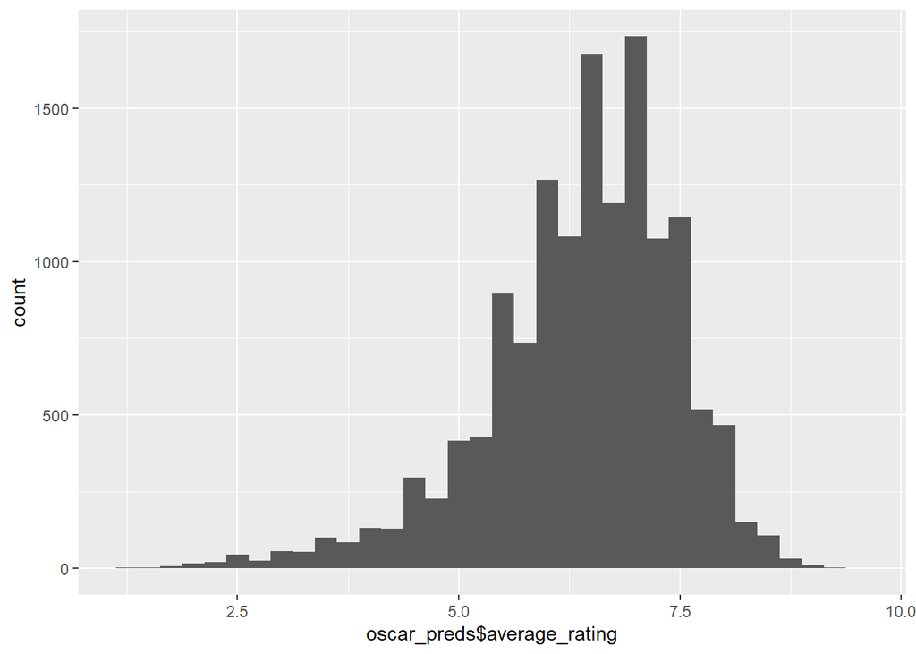

```r
# Check on the distribution of our average rating
ggplot(data=oscar_preds, aes(x=oscar_preds$average_rating)) +
  geom_histogram(binwidth = 0.25)
```

```r
stat.desc(oscar_preds[sample(nrow(oscar_preds), 5000), "average_rating"], basic = FALSE, norm = TRUE)
```

```
##        median          mean       SE.mean  CI.mean.0.95           var
##  6.500000e+00  6.374440e+00  1.572408e-02  3.082610e-02  1.236234e+00
##       std.dev      coef.var      skewness      skew.2SE      kurtosis
##  1.111861e+00  1.744248e-01 -9.310474e-01 -1.344254e+01  1.481412e+00
##      kurt.2SE    normtest.W    normtest.p
##  1.069651e+01  9.553411e-01  1.299385e-36
```

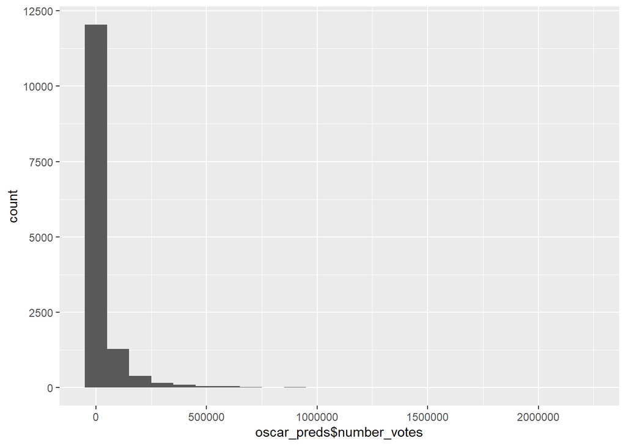

```r
# Check our distribution of number of votes... hmm something is askew here.
ggplot(data=oscar_preds, aes(x=oscar_preds$number_votes)) +
  geom_histogram(binwidth = 100000)
```

```r
# Whoa our skew and kurtosis is bad. As bad as your halitosis.
stat.desc(oscar_preds[sample(nrow(oscar_preds), 5000), "number_votes"], basic = FALSE, norm = TRUE)
```

```
##       median         mean      SE.mean CI.mean.0.95          var      std.dev
## 4.789500e+03 3.311068e+04 1.444677e+03 2.832201e+03 1.043546e+10 1.021541e+05
##     coef.var     skewness     skew.2SE     kurtosis     kurt.2SE   normtest.W
## 3.085232e+00 8.560561e+00 1.235981e+02 1.094610e+02 7.903611e+02 3.097787e-01
##   normtest.p
## 2.827658e-87
```

## Interesting Insights

Looking at a few other items from our data

```r
oscar_preds$genre.factor <- as.numeric(factor(oscar_preds$genre_1))
cor(oscar_preds$genre.factor,oscar_preds$have_win)^2
```

```
## [1] 0.0005164066
```

## Do you plan to slice and dice the data in different ways, create new variables, or join separate data frames to create new summary information? Explain.

I’ve displayed various ways already, by slicing the genre column into 3 columns. Adding a factor for the genre, subsetting out movies by runtime.

Also, one thing I skipped over so far was the Golden Globes data set. Mostly due to time constraints. I’m wondering if going back and adding this data would improve my modeling capabilities.

I’m still looking for additional ways to improve my data set!

## How could you summarize your data to answer key questions?

I did a basic correlation and it seems there is a very slight correlation between prior wins and winning an oscar in the current year.

```r
cor(oscar_preds[,c("have_win","prior_director_win","prior_actor_win","prior_writer_win","prior_other_win")])
```

```
##                      have_win prior_director_win prior_actor_win
## have_win           1.00000000         0.12165603       0.1122510
## prior_director_win 0.12165603         1.00000000       0.1462009
## prior_actor_win    0.11225101         0.14620085       1.0000000
## prior_writer_win   0.10362118         0.09423587       0.1524055
## prior_other_win    0.07230651         0.07935571       0.1088814
##                    prior_writer_win prior_other_win
## have_win                 0.10362118      0.07230651
## prior_director_win       0.09423587      0.07935571
## prior_actor_win          0.15240549      0.10888135
## prior_writer_win         1.00000000      0.05903764
## prior_other_win          0.05903764      1.00000000
```

I also looked at a cross tabulation of the various variables. While the output is a bit ugly, and not as pretty as some graphs R can produce, if you take a moment and look at the results provided, it is someone interesting. First and foremost, there are a lot of movies that are produced. And very few of them actually win Oscars. This tells me that I should probably look at a way to reduce my data set further to get a more focused model. But at this point in the project, that is beyond scope.

```r
# Show counts of different combinations
tb2 <- xtabs(~genre_1 + prior_director_win + prior_actor_win + prior_writer_win +
               prior_other_win + have_win, oscar_preds)

ftable(tb2)
```

```
##                                                                               have_win    0    1
## genre_1   prior_director_win prior_actor_win prior_writer_win prior_other_win
## Action    0                  0               0                0                        3657   50
##                                                               1                          52    5
##                                              1                0                          81    6
##                                                               1                           0    0
##                              1               0                0                         438   16
##                                                               1                          16    2
##                                              1                0                          42    7
##                                                               1                           7    2
##           1                  0               0                0                          85    2
##                                                               1                           6    0
##                                              1                0                           8    2
##                                                               1                           0    0
##                              1               0                0                          32    6
```

[output cut: 83 more lines]

I wanted to fit a model, since that was so much of our class this term. But for the life of me, I couldn’t find a good model. It turns out all of my variables are categorical, including my outcome variable. While this is not uncommon in data science, it does appear a little beyond my comprehension and skill set. And so while I fit a couple of models below, I’m not sure that their insights are actually all that helpful.

```r
# Fit a model
mod = glm(have_win ~ genre_1 + factor(prior_director_win) + factor(prior_actor_win) +
         factor(prior_writer_win) + factor(prior_other_win), data = oscar_preds,
         family = binomial())

confint(mod)
```

```
##                                   2.5 %     97.5 %
## (Intercept)                 -4.32866901 -3.9112630
## genre_1Adventure             0.87808309  1.4422939
## genre_1Biography             1.19847952  1.7649824
## genre_1Comedy                0.02414812  0.5850321
## genre_1Crime                -0.17006153  0.5431943
## genre_1Drama                 0.48327971  1.0534388
## factor(prior_director_win)1  0.76118126  1.2412717
## factor(prior_actor_win)1     0.62001076  0.9971647
## factor(prior_writer_win)1    0.72900439  1.2577952
## factor(prior_other_win)1     0.40337264  1.0311523
```

```r
summary(mod)
```

```
##
## Call:
## glm(formula = have_win ~ genre_1 + factor(prior_director_win) +
##     factor(prior_actor_win) + factor(prior_writer_win) + factor(prior_other_win),
##     family = binomial(), data = oscar_preds)
##
## Deviance Residuals:
##     Min       1Q   Median       3Q      Max
## -1.5787  -0.3118  -0.2094  -0.1801   2.8740
##
## Coefficients:
##                             Estimate Std. Error z value Pr(>|z|)
## (Intercept)                 -4.11385    0.10638 -38.672  < 2e-16 ***
## genre_1Adventure             1.15957    0.14374   8.067 7.20e-16 ***
## genre_1Biography             1.48093    0.14434  10.260  < 2e-16 ***
## genre_1Comedy                0.30417    0.14288   2.129   0.0333 *
## genre_1Crime                 0.19348    0.18151   1.066   0.2865
## genre_1Drama                 0.76814    0.14524   5.289 1.23e-07 ***
## factor(prior_director_win)1  1.00516    0.12238   8.213  < 2e-16 ***
## factor(prior_actor_win)1     0.81012    0.09617   8.424  < 2e-16 ***
## factor(prior_writer_win)1    0.99859    0.13476   7.410 1.26e-13 ***
## factor(prior_other_win)1     0.72594    0.15990   4.540 5.63e-06 ***
## ---
## Signif. codes:  0 '***' 0.001 '**' 0.01 '*' 0.05 '.' 0.1 ' ' 1
##
## (Dispersion parameter for binomial family taken to be 1)
##
##     Null deviance: 4897.4  on 14141  degrees of freedom
## Residual deviance: 4438.6  on 14132  degrees of freedom
## AIC: 4458.6
##
## Number of Fisher Scoring iterations: 6
```

```r
mod3 <- aov(have_win ~ genre_1 + factor(prior_director_win) + factor(prior_actor_win) +
      factor(prior_writer_win) + factor(prior_other_win), data = oscar_preds)

summary(mod3)
```

```
##                               Df Sum Sq Mean Sq F value   Pr(>F)
## genre_1                        5    9.2   1.832   48.01  < 2e-16 ***
## factor(prior_director_win)     1    6.8   6.849  179.52  < 2e-16 ***
## factor(prior_actor_win)        1    4.7   4.711  123.48  < 2e-16 ***
## factor(prior_writer_win)       1    3.4   3.396   89.02  < 2e-16 ***
## factor(prior_other_win)        1    1.2   1.195   31.32 2.23e-08 ***
## Residuals                  14132  539.2   0.038
## ---
## Signif. codes:  0 '***' 0.001 '**' 0.01 '*' 0.05 '.' 0.1 ' ' 1
```

Based on the summary of my models and the p-value outputs, my predictors are significant. But as stated, I’m not sure how accurate that is since none of them are continuous variables.

## Implications to the Target Audience

The biggest implication here is that with the data set I have put together, I don’t think we can make predictions. We can see that there is some impact to having previous winners and what genre a movie belongs to. But based on these factors alone, we can’t really make valuable predictions.

## Limitations of Analysis

With my skillset, the biggest limitation was the predictor variables I had chosen. Everything that we seemed to study had continuous variables and I couldn’t translate that only categorical. Additionly limitations were the dataset itself. While the data was large, it wasn’t particularly good in that I had to join to an external data set. For example, IMDb contains award information for multiple awards (Academy, Globes, AFI, etc) which could all be used to help predict winners.

Another factor that I think would be a great help in prediction would be rating and number of votes of a movie before the Academy Awards ceremony in which a film is eligible. If we can see what a movie is being rated at before it is awarded, it may indicate how a movie may fare. But since that is not possible with the current data set, I felt it would be too biased in that an Oscar awarded film would obviously be rated higher because it won an Oscar.

Another data source that I think would be very helpful would be critic reviews of a film, again especially before the award ceremony. But this is also an external data set. Initially I was thinking to use Twitter to collect this kind of data. But Rotten Tomatoes has an API available that provides access to critic and audience scores. So this may be a reasonable data source.

And finally, after I got all the way here, I realized I should have cut my data set down even more significantly. I should probably have only looked at films from the past 10-15 years. Not only has the film industry changed substantiably but so has how people consume media, which I believe impacts ratings and votes and even who wins an Award.

## Closing

I’m a little disappointed with how this projected ended up. I wanted to do something really cool and be able to predict who is going to win the Oscars next year. But while disappointing, it was valuable. I was able to re-inforce some techniques such as subsetting data, correlations, and plotting some graphs.

But in the end, I feel like I left a little on the table with this project!

### Apendix

Warning: Big ugly SQL below. Proceed with caution.

## SQL

I struggled with making my data usable. And I fell back to what I’m comfortable with and that is SQL. Part of my struggle is that using an external database and SQL scripts obfuscates some of the process. So to try and bring some transparency to my process, below is the query I utilized to pull the dataset I will use for my model.

```sql
SELECT  DISTINCT
        MIO.PRIMARY_TITLE,
        MIO.GENRES,
        MIO.START_YEAR,
        MAX(MIO.WIN) OVER (PARTITION BY PRIMARY_TITLE) AS HAVE_WIN,
        MIO.AVERAGE_RATING,
        MIO.NUMBER_VOTES,
        MPI.TITLE_CONSTANT,
        MPI.PRIOR_DIRECTOR_WIN,
        MPI.PRIOR_ACTOR_WIN,
        MPI.PRIOR_WRITER_WIN,
        MPI.PRIOR_OTHER_WIN
FROM    (   /*  GETS RELEVENT MOVIES BASED ON TYPE, YEAR, VOTES
                JOINS TO OSCARS TABLE TO GET WINNERS
                RETURNS BASIC DETAILS FOR FILM
            */
            SELECT  MI.TITLE_CONSTANT,
                    MI.PRIMARY_TITLE,
                    MI.START_YEAR,
                    MI.RUNTIME_MINUTES,
                    MI.GENRES,
                    O.CATEGORY,
                    O.NAME,
                    CASE
                        WHEN O.WIN IS NULL OR O.WIN = 'False'
                        THEN 0
                        ELSE 1
                    END AS WIN,
                    MI.AVERAGE_RATING,
                    MI.NUMBER_VOTES
            FROM    (   SELECT  T.TITLE_CONSTANT,
                                T.PRIMARY_TITLE,
                                T.START_YEAR,
                                T.RUNTIME_MINUTES,
                                T.GENRES,
                                R.AVERAGE_RATING,
                                R.NUMBER_VOTES
                        FROM    TITLES T
                        INNER JOIN
                                RATINGS R
                        ON      T.TITLE_CONSTANT = R.TITLE_CONSTANT
                        AND     T.IS_ADULT = 0
                        AND     T.TITLE_TYPE IN ('movie','short')
                        AND     T.START_YEAR >= 1927
                        AND     R.NUMBER_VOTES > 1000
                    ) MI
            LEFT JOIN
                    OSCARS O
            ON      LOWER(REGEXP_REPLACE(MI.PRIMARY_TITLE,'[[:punct:][:space:]]', '','g')) = LOWER(REGEXP_REPLACE(O.FILM,'[[:punct:][:space:]]', '','g'))
            AND     MI.START_YEAR = O.YEAR_FILM
            ORDER BY MI.TITLE_CONSTANT
    ) MIO
INNER JOIN
    (   SELECT  TITLE_CONSTANT,
                MAX(PRIOR_DIRECTOR_WIN) AS PRIOR_DIRECTOR_WIN,
                MAX(PRIOR_ACTOR_WIN) AS PRIOR_ACTOR_WIN,
                MAX(PRIOR_WRITER_WIN) AS PRIOR_WRITER_WIN,
                MAX(PRIOR_OTHER_WIN) AS PRIOR_OTHER_WIN
        FROM (
        SELECT  DISTINCT
                T.TITLE_CONSTANT,
                CASE
                    WHEN    CATEGORY = 'director'
                        AND YEAR_FIRST_WIN IS NOT NULL
                        AND YEAR_FIRST_WIN < T.START_YEAR
                    THEN
                        1
                    ELSE
                        0
                END AS PRIOR_DIRECTOR_WIN,
                CASE
                    WHEN    CATEGORY IN ('actor','actress')
                        AND YEAR_FIRST_WIN IS NOT NULL
                        AND YEAR_FIRST_WIN < T.START_YEAR
                    THEN
                        1
                    ELSE
                        0
                END AS PRIOR_ACTOR_WIN,
                CASE
                    WHEN    CATEGORY = 'writer'
                        AND YEAR_FIRST_WIN IS NOT NULL
                        AND YEAR_FIRST_WIN < T.START_YEAR
                    THEN
                        1
                    ELSE
                        0
                END AS PRIOR_WRITER_WIN,
                CASE
                    WHEN    CATEGORY NOT IN ('writer','actor','actress','director')
                        AND YEAR_FIRST_WIN IS NOT NULL
                        AND YEAR_FIRST_WIN < T.START_YEAR
                    THEN
                        1
                    ELSE
                        0
                END AS PRIOR_OTHER_WIN
        FROM    TITLES T
        INNER JOIN
                RATINGS R
        ON      T.TITLE_CONSTANT = R.TITLE_CONSTANT
        AND     T.IS_ADULT = 0
        AND     T.TITLE_TYPE IN ('movie','short')
        AND     T.START_YEAR >= 1927
        AND     R.NUMBER_VOTES > 1000
        INNER JOIN
                PRINCIPALS P
        ON      T.TITLE_CONSTANT = P.TITLE_CONSTANT
        INNER JOIN
                NAMES_FIRST_OSCAR NFO
        ON      P.NAME_CONSTANT = NFO.NAME_CONSTANT) A
        GROUP BY TITLE_CONSTANT
    ) MPI
ON  MIO.TITLE_CONSTANT = MPI.TITLE_CONSTANT;
```

It is big, and gnarly. But it is mostly straight forward. Most of the tables are directly from the datasets that I downloaded. One exception is table NAMES_FIRST_OSCAR which is a scaled down version of the NAMES table to indicate when a particular crew person won their first Oscar (if they won one).